# adaboost_regression

1. Practice Find a dataset with a continuous target variable.

Set the input (X) and output (y). Split the data into 60% training and 40% testing

Train an adaboost with 200 n_estimators and .1 learning rare. What is testing Rsquared of the adaboost?

What is the most important variable according to the above adatboost model?

Find an adaboost that have a higher testing accuracy than the above adaboost. What is the n_estimators and learning of this adaboost?

Plot the Training Rsquared of adaboosts with n_estimators running from 50 to 100 and two different learning rates. Give your comments on the plot.

Plot the Testing Rsquared with different with n_estimators running from 50 to 100 and two different learning rates. Give your comments on the plot.

1. Find a dataset with a continuous target variable.

```python
# Importing libraries
import pandas as pd
import numpy as np
from sklearn import tree
from sklearn import metrics
```

```python
# Importing data: source https://www.kaggle.com/datasets/nelgiriyewithana/billionaires-statistics-dataset

df = pd.read_csv('Billionaires Statistics Dataset.csv')
df.isna().sum()
```

```
rank                                             0
finalWorth                                       0
category                                         0
personName                                       0
age                                             65
country                                         38
city                                            72
source                                           0
industries                                       0
countryOfCitizenship                             0
organization                                  2315
selfMade                                         0
status                                           0
gender                                           0
birthDate                                       76
lastName                                         0
firstName                                        3
title                                         2301
date                                             0
state                                         1887
residenceStateRegion                          1893
birthYear                                       76
birthMonth                                      76
birthDay                                        76
cpi_country                                    184
cpi_change_country                             184
gdp_country                                    164
gross_tertiary_education_enrollment            182
gross_primary_education_enrollment_country     181
life_expectancy_country                        182
tax_revenue_country_country                    183
total_tax_rate_country                         182
population_country                             164
latitude_country                               164
longitude_country                              164
dtype: int64
```

```python
# Viewing column names
df.columns
```

```
Index(['rank', 'finalWorth', 'category', 'personName', 'age', 'country',
       'city', 'source', 'industries', 'countryOfCitizenship', 'organization',
       'selfMade', 'status', 'gender', 'birthDate', 'lastName', 'firstName',
       'title', 'date', 'state', 'residenceStateRegion', 'birthYear',
       'birthMonth', 'birthDay', 'cpi_country', 'cpi_change_country',
       'gdp_country', 'gross_tertiary_education_enrollment',
       'gross_primary_education_enrollment_country', 'life_expectancy_country',
       'tax_revenue_country_country', 'total_tax_rate_country',
       'population_country', 'latitude_country', 'longitude_country'],
      dtype='object')
```

1. Set the input (X) and output (y). Split the data into 60% training and 40% testing

```python
# Assign input variables
X = df.loc[:,['age', 'country',
       'selfMade', 'gender',
        'cpi_country',
       'gdp_country']]

# Assign target variable
y = df['finalWorth']
```

```python
# Checking for missing values
X.isna().sum()
```

```
age             65
country         38
selfMade         0
gender           0
cpi_country    184
gdp_country    164
dtype: int64
```

```python
# Removing missing values for the input variables.
X = X.dropna()
X.isna().sum()
```

```
age            0
country        0
selfMade       0
gender         0
cpi_country    0
gdp_country    0
dtype: int64
```

```python
# Checking the data types of the input variables.
X.dtypes
```

```
age            float64
country         object
selfMade          bool
gender          object
cpi_country    float64
gdp_country    float64
dtype: object
```

```python
# Changing the data types of two variables.
X['selfMade'] = X['selfMade'].astype(object)

X['gdp_country'] = X['gdp_country'].astype(float)
X.head()
```

|  | age | country | selfMade | gender | cpi_country | gdp_country |
| --- | --- | --- | --- | --- | --- | --- |
| 0 | 74.0 | France | False | M | 110.05 | 2.720000e+12 |
| 1 | 51.0 | United States | True | M | 117.24 | 2.140000e+13 |
| 2 | 59.0 | United States | True | M | 117.24 | 2.140000e+13 |
| 3 | 78.0 | United States | True | M | 117.24 | 2.140000e+13 |
| 4 | 92.0 | United States | True | M | 117.24 | 2.140000e+13 |

```python
# Encoding categorical variables and checking variable types.
X = pd.get_dummies(X)
X.dtypes
```

```
age                  float64
cpi_country          float64
gdp_country          float64
country_Algeria        uint8
country_Argentina      uint8
                      ...
country_Vietnam        uint8
selfMade_False         uint8
selfMade_True          uint8
gender_F               uint8
gender_M               uint8
Length: 71, dtype: object
```

```python
# Checking the number of observations in X and y.
print("X_obs:", len(X), "\ty_obs:", len(y))
```

```
X_obs: 2407 	y_obs: 2640
```

```python
# Reshaping dataframe.
y = y[:2407]
len(y)
```

```
2407
```

1. Train an adaboost with 200 n_estimators and .1 learning rare. What is testing Rsquared of the adaboost?

```python
# Partitioning data with a 40:60 testing:training split. The testing R-Squared produced by the model below is ~ 0.1316.
np.random.seed(64)
from sklearn.model_selection import train_test_split
x_train,x_test,y_train,y_test=train_test_split(X,y,test_size=0.4)

from sklearn.ensemble import AdaBoostRegressor
r1 = AdaBoostRegressor(n_estimators = 200, learning_rate = 0.1)
r1.fit(x_train, y_train)

# Rsquared
from sklearn.metrics import r2_score
print('Rsquared on Testing: ', r2_score(y_test, r1.predict(x_test)))
```

```
Rsquared on Testing:  0.1316142502370442
```

1. What is the most important variable according to the above adatboost model?

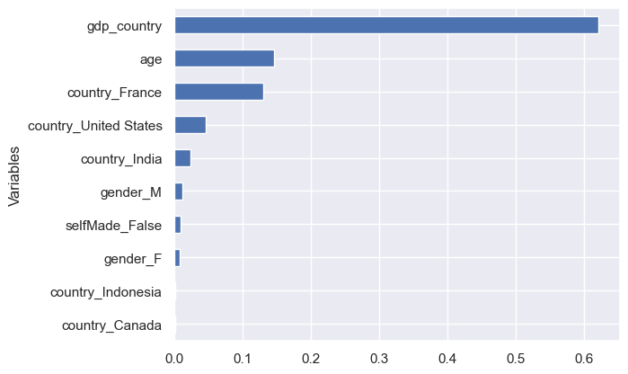

```python
# Plotting the variable importance from the model above
import warnings
warnings.filterwarnings("ignore")

sorted_idx = (-r1.feature_importances_).argsort()

feature_importance = pd.DataFrame({'Variables':x_train.columns[sorted_idx], 'Importance':r1.feature_importances_[sorted_idx]})
df = feature_importance[:10]
df.sort_values('Importance',inplace=True)

df.plot(kind='barh',y='Importance',x='Variables', legend=False)
```

From the variable importance plot above the most important varaible is `gdp_country`.

1. Find an adaboost that have a higher testing accuracy than the above adaboost. What is the n_estimators and learning of this adaboost?

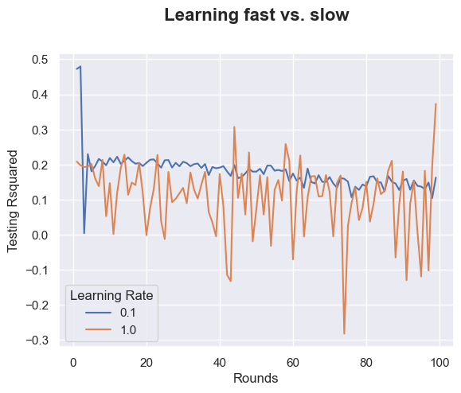

```python
# Plot the Testing R-Squared Accuracy of adaboosts with n_estimators running from n1 to n2 and two learning rates l1 and l2.
np.random.seed(64)
n1 = 1
n2 = 100
l1 = .1
l2 = 1

ac = pd.DataFrame([], columns=list(['Rounds','Learning Rate','Testing Rsquared']))
from sklearn.tree import DecisionTreeClassifier
for rs in range(n1, n2):
    for lr in [l1, l2]:
        boost = AdaBoostRegressor(n_estimators=rs, learning_rate=lr)
        boost.fit(x_train,y_train)
        ac = ac.append(pd.DataFrame([[rs, lr, boost.score(x_test,y_test) ]],
                                    columns=list(['Rounds','Learning Rate','Testing Rsquared'])), ignore_index=True)

import seaborn as sns; sns.set()
import matplotlib.pyplot as plt
ax = sns.lineplot(x="Rounds", y="Testing Rsquared", hue =ac['Learning Rate'].astype('category'),data=ac)
ax.text(x=0.5, y=1.1, s='Learning fast vs. slow', fontsize=16, weight='bold', ha='center', va='bottom', transform=ax.transAxes)
```

```python
# Creating the final model with the optimal hyper parameters.
np.random.seed(64)
from sklearn.ensemble import AdaBoostRegressor
r3 = AdaBoostRegressor(n_estimators = 2, learning_rate = 1)
r3.fit(x_train, y_train)

# Rsquared
from sklearn.metrics import r2_score
print('Rsquared on Testing: ', r2_score(y_test, r3.predict(x_test)))
```

```
Rsquared on Testing:  0.47226915004478887
```

The final model produced a testing R-Squared value of ~0.4723.

Final Parameters:

n_estimators = 2, learning_rate = 1

1. Plot the Training Rsquared of adaboosts with n_estimators running from 50 to 100 and two different learning rates. Give your comments on the plot.

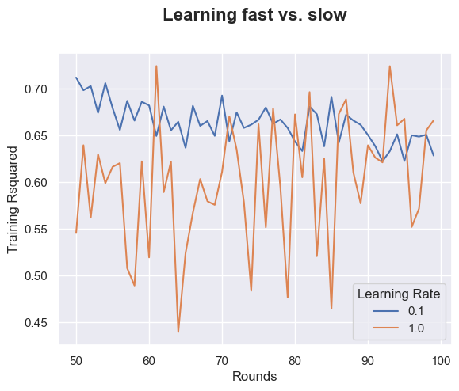

```python
# Plot the Training R-Squared of adaboosts with n_estimators running from n1 to n2 and two learning rates l1 and l2.
np.random.seed(64)
n1 = 50
n2 = 100
l1 = .1
l2 = 1

ac = pd.DataFrame([], columns=list(['Rounds','Learning Rate','Testing Rsquared']))
from sklearn.tree import DecisionTreeClassifier
for rs in range(n1, n2):
    for lr in [l1, l2]:
        boost = AdaBoostRegressor(n_estimators=rs, learning_rate=lr)
        boost.fit(x_train,y_train)
        ac = ac.append(pd.DataFrame([[rs, lr, boost.score(x_train,y_train) ]],
                                    columns=list(['Rounds','Learning Rate','Training Rsquared'])), ignore_index=True)

import seaborn as sns; sns.set()
import matplotlib.pyplot as plt
ax = sns.lineplot(x="Rounds", y="Training Rsquared", hue =ac['Learning Rate'].astype('category'),data=ac)
ax.text(x=0.5, y=1.1, s='Learning fast vs. slow', fontsize=16, weight='bold', ha='center', va='bottom', transform=ax.transAxes)
```

In the plot above, it is clear that a lower learning rate is better than a higher one for producing a training higher R-Squared especially at lower values for n_estimators.

1. Plot the Testing Rsquared with different with n_estimators running from 50 to 100 and two different learning rates. Give your comments on the plot.

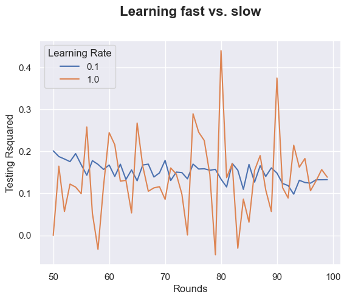

```python
# Plot the Testing R-Squared of adaboosts with n_estimators running from n1 to n2 and two learning rates l1 and l2.
np.random.seed(64)
n1 = 50
n2 = 100
l1 = .1
l2 = 1

ac = pd.DataFrame([], columns=list(['Rounds','Learning Rate','Testing Rsquared']))
from sklearn.tree import DecisionTreeClassifier
for rs in range(n1, n2):
    for lr in [l1, l2]:
        boost = AdaBoostRegressor(n_estimators=rs, learning_rate=lr)
        boost.fit(x_train,y_train)
        ac = ac.append(pd.DataFrame([[rs, lr, boost.score(x_test,y_test) ]],
                                    columns=list(['Rounds','Learning Rate','Testing Rsquared'])), ignore_index=True)

import seaborn as sns; sns.set()
import matplotlib.pyplot as plt
ax = sns.lineplot(x="Rounds", y="Testing Rsquared", hue =ac['Learning Rate'].astype('category'),data=ac)
ax.text(x=0.5, y=1.1, s='Learning fast vs. slow', fontsize=16, weight='bold', ha='center', va='bottom', transform=ax.transAxes)
```

From the plot above, it is evident that the testing R-Squared varies much more when the learning rate is set to 1. However, the learning rate of 1 produced the highest testing R-Squared when the hyperparameter 'n_estimators = 80'